# Final Project Report - Practical Machine Learning Course

## Background & Introduction

This document was prepared as part of the final assignment in the Practical Machine Learning course. In the next paragraph is a summary of the problem to be solved.

Using devices such as Jawbone Up, Nike FuelBand, and Fitbit it is now possible to collect a large amount of data about personal activity relatively inexpensively. These type of devices are part of the quantified self movement - a group of enthusiasts who take measurements about themselves regularly to improve their health, to find patterns in their behavior, or because they are tech geeks. One thing that people regularly do is quantify how much of a particular activity they do, but they rarely quantify how well they do it. In this project, your goal will be to use data from accelerometers on the belt, forearm, arm, and dumbell of 6 participants. They were asked to perform barbell lifts correctly and incorrectly in 5 different ways. More information is available from the website here: http://groupware.les.inf.puc-rio.br/har (see the section on the Weight Lifting Exercise Dataset).

## Data

The training data for this project are available here:

https://d396qusza40orc.cloudfront.net/predmachlearn/pml-training.csv

The test data are available here:

https://d396qusza40orc.cloudfront.net/predmachlearn/pml-testing.csv

## Project Objective

The goal of this project is to predict the manner in which the participants did the exercise, by predicting the depepndent variable “classe” using the datasets provided.

## Project code and steps

The project code used and the steps followed are contained in this section and should enable reproducability of the project whenever required.

Install (if not already installed) and load the packages below:

```r
library(caret);library(rpart);library(rpart.plot);library(RColorBrewer);library(rattle);library(randomForest)
```

Set a pseudo random number with the code:

```r
set.seed(2499)
```

Create the data objects for both the training and test data provided in the Data section of this document. To download the data, create data objects for the training and test data sources as indicated below:

```r
train_source<-"https://d396qusza40orc.cloudfront.net/predmachlearn/pml-training.csv"
test_source<-"https://d396qusza40orc.cloudfront.net/predmachlearn/pml-testing.csv"
```

Next, create the data objects using the code below:

```r
training<-read.csv(url(train_source), na.strings=c("NA","#DIV/0!",""))
testing<-read.csv(url(test_source),na.strings = c("NA","#DIV/0!",""))
```

Confirm datasets.

```r
names(training)
```

```
##   [1] "X"                        "user_name"
##   [3] "raw_timestamp_part_1"     "raw_timestamp_part_2"
##   [5] "cvtd_timestamp"           "new_window"
##   [7] "num_window"               "roll_belt"
##   [9] "pitch_belt"               "yaw_belt"
##  [11] "total_accel_belt"         "kurtosis_roll_belt"
##  [13] "kurtosis_picth_belt"      "kurtosis_yaw_belt"
##  [15] "skewness_roll_belt"       "skewness_roll_belt.1"
##  [17] "skewness_yaw_belt"        "max_roll_belt"
##  [19] "max_picth_belt"           "max_yaw_belt"
##  [21] "min_roll_belt"            "min_pitch_belt"
##  [23] "min_yaw_belt"             "amplitude_roll_belt"
##  [25] "amplitude_pitch_belt"     "amplitude_yaw_belt"
##  [27] "var_total_accel_belt"     "avg_roll_belt"
##  [29] "stddev_roll_belt"         "var_roll_belt"
```

[output cut: 65 more lines]

```r
dim(training)
```

```
## [1] 19622   160
```

```r
names(testing)
```

```
##   [1] "X"                        "user_name"
##   [3] "raw_timestamp_part_1"     "raw_timestamp_part_2"
##   [5] "cvtd_timestamp"           "new_window"
##   [7] "num_window"               "roll_belt"
##   [9] "pitch_belt"               "yaw_belt"
##  [11] "total_accel_belt"         "kurtosis_roll_belt"
##  [13] "kurtosis_picth_belt"      "kurtosis_yaw_belt"
##  [15] "skewness_roll_belt"       "skewness_roll_belt.1"
##  [17] "skewness_yaw_belt"        "max_roll_belt"
##  [19] "max_picth_belt"           "max_yaw_belt"
##  [21] "min_roll_belt"            "min_pitch_belt"
##  [23] "min_yaw_belt"             "amplitude_roll_belt"
##  [25] "amplitude_pitch_belt"     "amplitude_yaw_belt"
##  [27] "var_total_accel_belt"     "avg_roll_belt"
##  [29] "stddev_roll_belt"         "var_roll_belt"
```

[output cut: 65 more lines]

```r
dim(testing)
```

```
## [1]  20 160
```

## Data Partitioning

Split the training dataset into Train and Test at a ratio of 60% to 40% using the data partition function in the caret package.

```r
inTrain <- createDataPartition(y=training$classe, p=0.6, list=FALSE)
Train_data<-training[inTrain,]
Test_data<-training[-inTrain,]
```

Check the sizes of the partitioned datasets.

```r
dim(Train_data)
```

```
## [1] 11776   160
```

```r
dim(Test_data)
```

```
## [1] 7846  160
```

## Data Cleanup

Remove any unnecessary fields from the datasets.

```r
Train_data<-Train_data[,-(1:5)]
names(Train_data)
```

```
##   [1] "new_window"               "num_window"
##   [3] "roll_belt"                "pitch_belt"
##   [5] "yaw_belt"                 "total_accel_belt"
##   [7] "kurtosis_roll_belt"       "kurtosis_picth_belt"
##   [9] "kurtosis_yaw_belt"        "skewness_roll_belt"
##  [11] "skewness_roll_belt.1"     "skewness_yaw_belt"
##  [13] "max_roll_belt"            "max_picth_belt"
##  [15] "max_yaw_belt"             "min_roll_belt"
##  [17] "min_pitch_belt"           "min_yaw_belt"
##  [19] "amplitude_roll_belt"      "amplitude_pitch_belt"
##  [21] "amplitude_yaw_belt"       "var_total_accel_belt"
##  [23] "avg_roll_belt"            "stddev_roll_belt"
##  [25] "var_roll_belt"            "avg_pitch_belt"
##  [27] "stddev_pitch_belt"        "var_pitch_belt"
##  [29] "avg_yaw_belt"             "stddev_yaw_belt"
```

[output cut: 63 more lines]

```r
Test_data<-Test_data[,-(1:5)]
names(Test_data)
```

```
##   [1] "new_window"               "num_window"
##   [3] "roll_belt"                "pitch_belt"
##   [5] "yaw_belt"                 "total_accel_belt"
##   [7] "kurtosis_roll_belt"       "kurtosis_picth_belt"
##   [9] "kurtosis_yaw_belt"        "skewness_roll_belt"
##  [11] "skewness_roll_belt.1"     "skewness_yaw_belt"
##  [13] "max_roll_belt"            "max_picth_belt"
##  [15] "max_yaw_belt"             "min_roll_belt"
##  [17] "min_pitch_belt"           "min_yaw_belt"
##  [19] "amplitude_roll_belt"      "amplitude_pitch_belt"
##  [21] "amplitude_yaw_belt"       "var_total_accel_belt"
##  [23] "avg_roll_belt"            "stddev_roll_belt"
##  [25] "var_roll_belt"            "avg_pitch_belt"
##  [27] "stddev_pitch_belt"        "var_pitch_belt"
##  [29] "avg_yaw_belt"             "stddev_yaw_belt"
```

[output cut: 63 more lines]

Perform function to remove columns where NA values exist

```r
Data_Na<-sapply(Train_data,function(x)mean(is.na(x)))>0.95
Train_data<-Train_data[,Data_Na==FALSE]
dim(Train_data)
```

```
## [1] 11776    55
```

```r
Test_data<-Test_data[,Data_Na==FALSE]
dim(Test_data)
```

```
## [1] 7846   55
```

Remove Near zero variance variables.

```r
NZV<-nearZeroVar(Train_data)
Train_data<-Train_data[,-NZV]
dim(Train_data)
```

```
## [1] 11776    54
```

```r
Test_data<-Test_data[,-NZV]
dim(Test_data)
```

```
## [1] 7846   54
```

# Model building and selection

```r
set.seed(2499)
RF_ctrl<-trainControl(method = "cv",number = 3,verboseIter = FALSE) #set validation
RF_ModelFit<-train(classe~.,data = Train_data,method="rf",trControl=RF_ctrl)
RF_ModelFit$finalModel
```

```
##
## Call:
##  randomForest(x = x, y = y, mtry = param$mtry)
##                Type of random forest: classification
##                      Number of trees: 500
## No. of variables tried at each split: 27
##
##         OOB estimate of  error rate: 0.27%
## Confusion matrix:
##      A    B    C    D    E class.error
## A 3348    0    0    0    0 0.000000000
## B    7 2267    5    0    0 0.005265467
## C    0    5 2047    2    0 0.003407984
## D    0    0    6 1923    1 0.003626943
## E    0    0    0    6 2159 0.002771363
```

Prediction.

```r
RF_ModelPred<-predict(RF_ModelFit,newdata=Test_data)
conf_matrix_RF<-confusionMatrix(RF_ModelPred,Test_data$classe)
conf_matrix_RF
```

```
## Confusion Matrix and Statistics
##
##           Reference
## Prediction    A    B    C    D    E
##          A 2231    5    0    0    0
##          B    0 1512    0    0    0
##          C    0    1 1368    7    0
##          D    0    0    0 1278    2
##          E    1    0    0    1 1440
##
## Overall Statistics
##
##                Accuracy : 0.9978
##                  95% CI : (0.9965, 0.9987)
##     No Information Rate : 0.2845
##     P-Value [Acc > NIR] : < 2.2e-16
##
##                   Kappa : 0.9973
##  Mcnemar's Test P-Value : NA
##
## Statistics by Class:
##
##                      Class: A Class: B Class: C Class: D Class: E
## Sensitivity            0.9996   0.9960   1.0000   0.9938   0.9986
## Specificity            0.9991   1.0000   0.9988   0.9997   0.9997
## Pos Pred Value         0.9978   1.0000   0.9942   0.9984   0.9986
## Neg Pred Value         0.9998   0.9991   1.0000   0.9988   0.9997
## Prevalence             0.2845   0.1935   0.1744   0.1639   0.1838
## Detection Rate         0.2843   0.1927   0.1744   0.1629   0.1835
## Detection Prevalence   0.2850   0.1927   0.1754   0.1631   0.1838
## Balanced Accuracy      0.9993   0.9980   0.9994   0.9967   0.9992
```

# Model: Generalized Boosted Model

```r
set.seed(2499)
#GBM_ctrl<-trainControl(method = "repeatedcv",number = 5,repeats = 1,verboseIter = TRUE)
#GMB_ModelFit<-train(classe~.,data = Train_data,method="gbm",trControl=GBM_ctrl)
#GBM_ModelFit$finalModel

GBM_ctrl <- trainControl(method = "repeatedcv", number = 5, repeats = 1)
GMB_ModelFit  <- train(classe ~ ., data=Train_data, method = "gbm",
                    trControl = GBM_ctrl, verbose = FALSE)
GMB_ModelFit$finalModel
```

```
## A gradient boosted model with multinomial loss function.
## 150 iterations were performed.
## There were 53 predictors of which 42 had non-zero influence.
```

Prediction.

```r
#GBM_ModelPred<-predict(GBM_ModelFit,newdata=Test_data,type="class")
#conf_matrixGBM<-confusionMatrix(GBM_ModelPred,Test_data$classe)
#conf_matrixGBM

GBM_ModelPred <- predict(GMB_ModelFit, newdata=Test_data)
conf_matrixGBM <- confusionMatrix(GBM_ModelPred, Test_data$classe)
conf_matrixGBM
```

```
## Confusion Matrix and Statistics
##
##           Reference
## Prediction    A    B    C    D    E
##          A 2227   14    0    1    1
##          B    3 1485    6    6    4
##          C    0   17 1354   16    4
##          D    0    2    7 1259   11
##          E    2    0    1    4 1422
##
## Overall Statistics
##
##                Accuracy : 0.9874
##                  95% CI : (0.9847, 0.9897)
##     No Information Rate : 0.2845
##     P-Value [Acc > NIR] : < 2.2e-16
##
##                   Kappa : 0.984
##  Mcnemar's Test P-Value : NA
##
## Statistics by Class:
##
##                      Class: A Class: B Class: C Class: D Class: E
## Sensitivity            0.9978   0.9783   0.9898   0.9790   0.9861
## Specificity            0.9971   0.9970   0.9943   0.9970   0.9989
## Pos Pred Value         0.9929   0.9874   0.9734   0.9844   0.9951
## Neg Pred Value         0.9991   0.9948   0.9978   0.9959   0.9969
## Prevalence             0.2845   0.1935   0.1744   0.1639   0.1838
## Detection Rate         0.2838   0.1893   0.1726   0.1605   0.1812
## Detection Prevalence   0.2859   0.1917   0.1773   0.1630   0.1821
## Balanced Accuracy      0.9975   0.9876   0.9920   0.9880   0.9925
```

# Model: Decision Trees

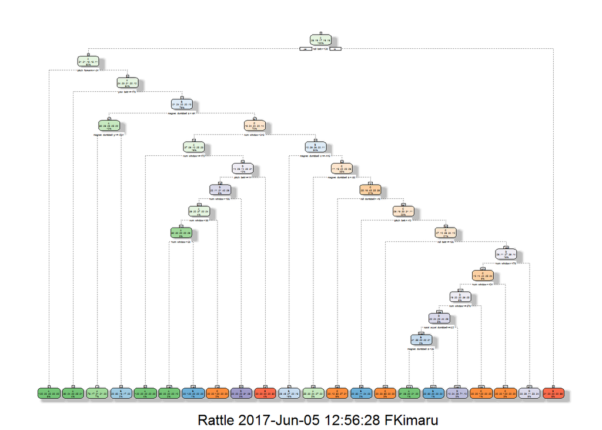

```r
set.seed(2499)
DT_ModelFit<-rpart(classe~.,data = Train_data,method = "class")
fancyRpartPlot(DT_ModelFit)
```

Prediction

```r
DT_ModelPred<-predict(DT_ModelFit,newdata=Test_data,type="class")
Conf_matrix_DT<-confusionMatrix(DT_ModelPred,Test_data$classe)
Conf_matrix_DT
```

```
## Confusion Matrix and Statistics
##
##           Reference
## Prediction    A    B    C    D    E
##          A 2063  239   22   56   39
##          B  116 1117  160  365  276
##          C    0   90 1084   48    2
##          D   48   72  102  762  235
##          E    5    0    0   55  890
##
## Overall Statistics
##
##                Accuracy : 0.754
##                  95% CI : (0.7443, 0.7635)
##     No Information Rate : 0.2845
##     P-Value [Acc > NIR] : < 2.2e-16
##
##                   Kappa : 0.6875
##  Mcnemar's Test P-Value : < 2.2e-16
##
## Statistics by Class:
##
##                      Class: A Class: B Class: C Class: D Class: E
## Sensitivity            0.9243   0.7358   0.7924  0.59253   0.6172
## Specificity            0.9366   0.8551   0.9784  0.93034   0.9906
## Pos Pred Value         0.8528   0.5492   0.8856  0.62510   0.9368
## Neg Pred Value         0.9689   0.9310   0.9571  0.92093   0.9200
## Prevalence             0.2845   0.1935   0.1744  0.16391   0.1838
## Detection Rate         0.2629   0.1424   0.1382  0.09712   0.1134
## Detection Prevalence   0.3083   0.2592   0.1560  0.15537   0.1211
## Balanced Accuracy      0.9304   0.7955   0.8854  0.76144   0.8039
```

# Model selection & Application to Testing data

When applied to the testing data, the prediction would be as indicated below:

```r
TEST_Pred<- predict(RF_ModelFit,newdata=testing)
TEST_Pred
```

```
##  [1] B A B A A E D B A A B C B A E E A B B B
## Levels: A B C D E
```